# Project Course 2

Daniel Castineyra

8 de diciembre de 2017

# Most harmful weather events in the US from 1950 to 2011

## Data Processing

1. We read the data directly from the bzip file.
2. Subset and creating a new database the data only for the variables relevant for the study, i.e. Fatalities and Injuries (health) and Property and Crop damaged (economic).
3. Create two variables, one that sum the fatalities and injuries, and another that sum the property and crop damage.

```r
datos<-read.csv(zz<-bzfile("repdata%2FData%2FStormData.bz2"),header=TRUE,sep=",")
library(dplyr)
## Subsetting the data
harmful<-datos[,c("EVTYPE","FATALITIES","INJURIES","PROPDMG","CROPDMG")]
## Getting the total health and economic damage
harmful<-mutate(harmful,health = FATALITIES + INJURIES)
harmful<-mutate(harmful,economic = PROPDMG + CROPDMG)
```

## Results

1. Across the United States which types of events are most harmful with respect to population health?

To answer this question, we are going to measure the variables total injuries and fatalities by event type.

The table below shows the top 10 events most harmful with respect to fatalities and injuries (health)

```r
## Getting the total fatalitites and injuries by event type
by_event<-harmful %>% group_by(EVTYPE)
healthdmg<- summarise(by_event,health = sum(health))
hdmg <- data.frame(Event = healthdmg$EVTYPE, Health_DMG = healthdmg$health)
##sorting
hdmg<- hdmg[with(hdmg,order(-Health_DMG)),]
## Getting the top 10 events most harmful with respect to fatalities and injurires
top10<-head(hdmg,n=10L)
top10
```

```
##                 Event Health_DMG
## 834           TORNADO      96979
## 130    EXCESSIVE HEAT       8428
## 856         TSTM WIND       7461
## 170             FLOOD       7259
## 464         LIGHTNING       6046
## 275              HEAT       3037
## 153       FLASH FLOOD       2755
## 427         ICE STORM       2064
## 760 THUNDERSTORM WIND       1621
## 972      WINTER STORM       1527
```

The below plot shows the same results.

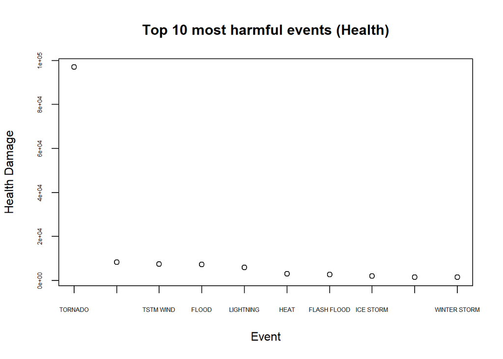

```r
par(cex.axis=.5)
plot(top10$Health_DMG,xlab="Event",ylab="Health Damage",main="Top 10 most harmful events (Health)",xaxt="n")
axis(side=1,at=1:10,labels=top10$Event)
```

2. Across the United States, which types of events have the grates economic consequences?

To answer this question, we are going to measure the variables total property and crop damage by event type.

The table below shows the top 10 events most harmful with respect to property and crop damage (economic)

```r
## Getting the total property and crop damage by event
ecodmg<- summarise(by_event,economic = sum(economic))
edmg <- data.frame(Event = ecodmg$EVTYPE, Economic_DMG = ecodmg$economic)
##sorting
edmg<- edmg[with(edmg,order(-Economic_DMG)),]
## Getting the top 10 events most harmful with respect to property and crop damage
top10e<-head(edmg,n=10L)
top10e
```

```
##                  Event Economic_DMG
## 834            TORNADO    3312276.7
## 153        FLASH FLOOD    1599325.1
## 856          TSTM WIND    1445168.2
## 244               HAIL    1268289.7
## 170              FLOOD    1067976.4
## 760  THUNDERSTORM WIND     943635.6
## 464          LIGHTNING     606932.4
## 786 THUNDERSTORM WINDS     464978.1
## 359          HIGH WIND     342014.8
## 972       WINTER STORM     134699.6
```

The below plot shows the same results.

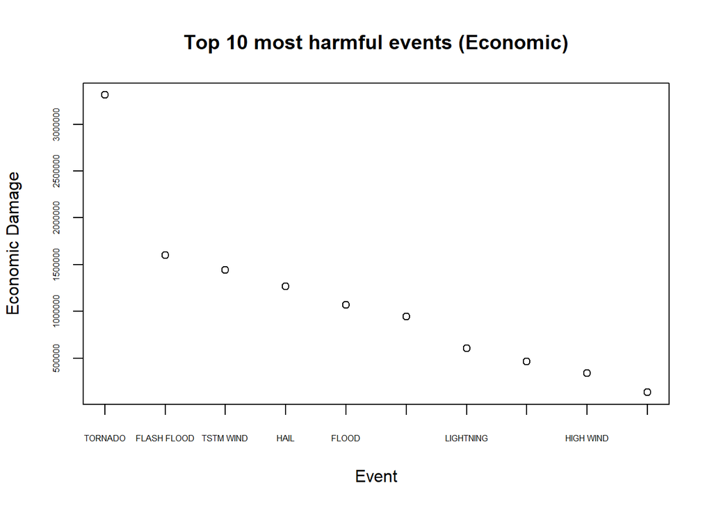

```r
par(cex.axis=.5)
plot(top10e$Economic_DMG,xlab="Event",ylab="Economic Damage",main="Top 10 most harmful events (Economic)",xaxt="n")
axis(side=1,at=1:10,labels=top10e$Event)
```